# Análisis de regresión lineal — Cohorte ERC

Factores asociados a la tasa de declive de la TFG

Wendy Paola Rodríguez Pugliesse

2026-11-08

```r
library(tidyverse)
library(here)
library(gtsummary)
library(broom)
library(car)

base <- readRDS(here("data", "processed", "base_analitica_v1.0.rds")) %>%
  # Factor nominal para que G2 sea la categoría de referencia
  mutate(estadio_basal = factor(estadio_basal, ordered = FALSE))

base_lineal <- base %>%
  filter(!is.na(tasa_declive_tfg),
         !is.na(estadio_basal),
         !is.na(log_proteinuria_basal))

cat("N analítico:", nrow(base_lineal), "\n")
```

```
## N analítico: 246
```

```r
cat("Excluidos (sin TFG al mes 24):", nrow(base) - nrow(base_lineal), "\n")
```

```
## Excluidos (sin TFG al mes 24): 54
```

```r
cat("Tasa de declive (mediana):",
    round(median(base_lineal$tasa_declive_tfg, na.rm = TRUE), 1),
    "mL/min/año\n")
```

```
## Tasa de declive (mediana): -4.5 mL/min/año
```

La tasa de declive solo puede calcularse en quienes tienen TFG al mes 24, por lo que se excluyen 54 participantes (principalmente por pérdida de seguimiento).

# 1 Distribución del desenlace

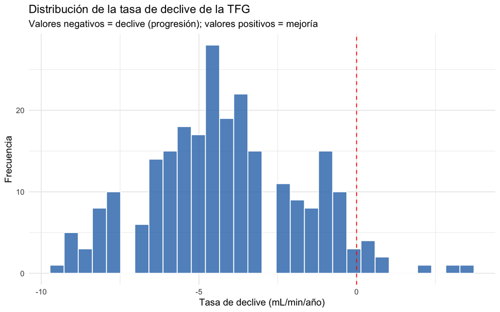

```r
ggplot(base_lineal, aes(x = tasa_declive_tfg)) +
  geom_histogram(bins = 30, fill = "#2E75B6", color = "white", alpha = 0.8) +
  geom_vline(xintercept = 0, linetype = "dashed", color = "red") +
  labs(title = "Distribución de la tasa de declive de la TFG",
       subtitle = "Valores negativos = declive (progresión); valores positivos = mejoría",
       x = "Tasa de declive (mL/min/año)",
       y = "Frecuencia") +
  theme_minimal()
```

El 95.1% de los participantes presentó declive de la TFG (valores negativos), con una mediana de -4.5 mL/min/año (rango -9.5 a 3.5). La distribución es aproximadamente simétrica, sin sesgo marcado, lo que es compatible con el uso de regresión lineal.

# 2 Modelo crudo

```r
modelo_crudo <- lm(tasa_declive_tfg ~ estadio_basal, data = base_lineal)

tbl_regression(modelo_crudo,
               label = list(estadio_basal ~ "Estadio de ERC (ref: G2)")) %>%
  bold_p(t = 0.05) %>%
  bold_labels() %>%
  modify_caption("**Tabla 1. Coeficientes crudos para tasa de declive de TFG**")
```

**Tabla 1. Coeficientes crudos para tasa de declive de TFG**

| **Characteristic** | **Beta** | **95% CI** | **p-value** |
| --- | --- | --- | --- |
| Estadio de ERC (ref: G2) |  |  |  |
| G2 | — | — |  |
| G3a | 0.04 | -0.76, 0.84 | >0.9 |
| G3b | -0.11 | -0.95, 0.73 | 0.8 |
| G4 | -1.8 | -2.7, -0.92 | <0.001 |

Abbreviation: CI = Confidence Interval

# 3 Modelo ajustado

```r
modelo_lineal <- lm(
  tasa_declive_tfg ~ estadio_basal + edad + sexo +
    diabetes + hipertension +
    log_proteinuria_basal + hemoglobina_g_dl_basal +
    pas_mmhg_basal + ieca_o_ara2,
  data = base_lineal
)

tbl_regression(modelo_lineal,
               label = list(
                 estadio_basal          ~ "Estadio de ERC (ref: G2)",
                 edad                   ~ "Edad (por año)",
                 sexo                   ~ "Sexo",
                 diabetes               ~ "Diabetes mellitus",
                 hipertension           ~ "Hipertensión arterial",
                 log_proteinuria_basal  ~ "Log-proteinuria (por unidad)",
                 hemoglobina_g_dl_basal ~ "Hemoglobina (por g/dL)",
                 pas_mmhg_basal         ~ "PAS (por mmHg)",
                 ieca_o_ara2            ~ "IECA o ARA2"
               )) %>%
  add_glance_source_note(include = c(r.squared, adj.r.squared, nobs)) %>%
  bold_p(t = 0.05) %>%
  bold_labels() %>%
  modify_caption("**Tabla 2. Coeficientes ajustados para tasa de declive de TFG**")
```

**Tabla 2. Coeficientes ajustados para tasa de declive de TFG**

| **Characteristic** | **Beta** | **95% CI** | **p-value** |
| --- | --- | --- | --- |
| Estadio de ERC (ref: G2) |  |  |  |
| G2 | — | — |  |
| G3a | 0.05 | -0.75, 0.85 | >0.9 |
| G3b | -0.05 | -0.88, 0.78 | >0.9 |
| G4 | -1.9 | -2.8, -1.0 | <0.001 |
| Edad (por año) | 0.00 | -0.02, 0.03 | 0.8 |
| Sexo |  |  |  |
| Femenino | — | — |  |
| Masculino | -0.01 | -0.59, 0.57 | >0.9 |
| Diabetes mellitus |  |  |  |
| FALSE | — | — |  |
| TRUE | -0.71 | -1.3, -0.11 | 0.021 |
| Hipertensión arterial |  |  |  |
| FALSE | — | — |  |
| TRUE | -0.07 | -0.94, 0.80 | 0.9 |
| Log-proteinuria (por unidad) | -0.10 | -0.37, 0.17 | 0.5 |
| Hemoglobina (por g/dL) | -0.15 | -0.32, 0.02 | 0.082 |
| PAS (por mmHg) | 0.00 | -0.01, 0.02 | 0.6 |
| IECA o ARA2 |  |  |  |
| FALSE | — | — |  |
| TRUE | -0.87 | -1.5, -0.27 | 0.005 |

Abbreviation: CI = Confidence Interval  
R² = 0.148; Adjusted R² = 0.108; No. Obs. = 246

```r
coefs <- tidy(modelo_lineal, conf.int = TRUE)
b <- function(term) round(coefs$estimate[coefs$term == term], 2)
p <- function(term) format.pval(coefs$p.value[coefs$term == term], digits = 2, eps = 0.001)
```

Un coeficiente negativo indica un declive más rápido. Tras el ajuste, el estadio G4 presentó un declive 1.93 mL/min/año más rápido que G2 (p = <0.001), mientras que G3a y G3b no difirieron de G2. La diabetes (β = -0.71, p = 0.021) y el uso de IECA/ARA2 (β = -0.87, p = 0.0048) también se asociaron con declive más rápido. Esta última asociación es probablemente confusión por indicación (los IECA/ARA2 se prescriben a pacientes con enfermedad más activa) y no un efecto causal. La edad, el sexo, la HTA, la log-proteinuria y la PAS no mostraron asociación significativa. El modelo explica una fracción modesta de la variabilidad (R² = 0.15).